The Fukushima disaster Constantin T Yiannoutsos November 9, 2022

# Introduction

In this vignette I discuss a well-known event, the Fukushima disaster. This event takes its name from the Fukushima Daiichi nuclear power plant in the Fukushima prefecture on the island of Honshu, Japan. On 11 March 2011 and 05:46:24 UTC, a magnitude 9.1 earthquake occurred off the coast near the plant, creating a tsunami wave that resulted in a catastrophic reactor meltdown destroying the plant. This disaster had ripple effects for Japan’s entire nuclear power program as well as the broader Japanese economy.

As mentioned by Nate Silver, in his book *The Signal and the Noise: Why So Many Predictions Fail-but Some Don’t* (2012, Penguin Group), the Fukushima accident may have been caused by faulty construction based on erroneous assumptions about the likelihood of such a catastrophic event. The author’s argument is related to the interpretation, or rather over-interpretation, of regression models. So, as I am teaching a regression course, my interest was piqued. Before we discuss Mr. Silver’s argument or anything about modeling and statistics, let’s go back and review some fundamental ideas about earthquakes.

## The Gutenberg-Richter law

The Gutenberg-Richter law specifies the annual chance of an earthquake happening as a function of its magnitude. The relationship connecting the frequency of an earthquake with its magnitude is
$$f=10^{a+bM}$$
where $f$ is the frequency and $M$ is the magnitude (on the Richter scale) of the earthquake. Taking log-base-10 on both sides of the above equation we get
$$\log_{10}(f)=a+bM$$
In other words, the Gutenberg-Richter Law specifies that the log-base-10-transformed frequency of earthquakes is a linear function of their magnitude, up to unknown constants $a$ and $b$. The coefficient $b$ or “b-value” is typically in the range of -1.1 to -0.8 (i.e., $b<0$), underlining the key assumption of the model that larger magnitude earthquakes are less frequent than earthquakes of smaller magnitude.

The log-10 transformation implies that an earthquake that is one-unit stronger on the Richter scale, will have a chance of occurring that is $1/10\times b$ compared to an earthquake that is one-unit smaller. If $b=-1$ and the frequency of an earthquake of size $M=5$ is, on average, once a year (i.e., $f_5=1$), then the likelihood of a magnitude-7 earthquake is
$$\log\left (\frac{f_7}{f_5}\right
)=\log(f_7)-\log(f_5)=a+(-1)(7)-a+(-1)(5)=-2$$

Consequently, the frequency of an earthquake of magnitude 7 is
$$f_7=10^{-2}=0.01$$
or 1 in a hundred. So, if a magnitude-5 earthquake happens once a year, according to the Gutemberg-Richter model a magnitude-7 earthquake is expected to happen, on average, once in one hundred years.

## Along comes Nate

So along comes Nate Silver, showing the following figure in his book:

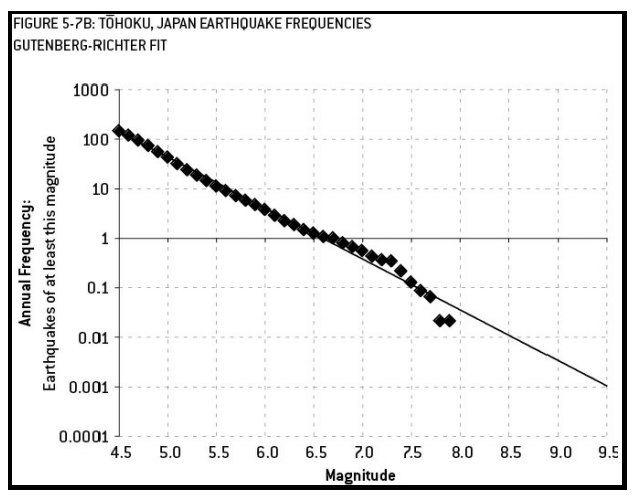

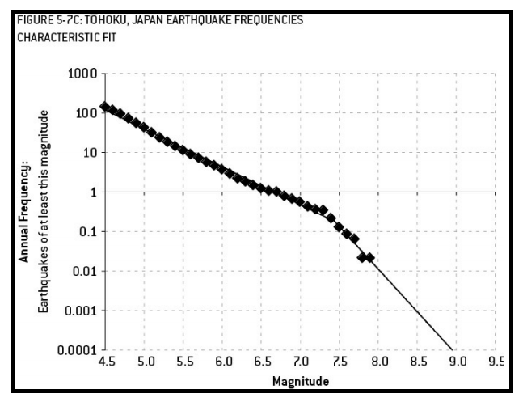

According to Mr. Silver’s commentary, the estimates produced by this alternative analysis (or over-analysis) of the data, result in an estimate of observing a magnitude $M=9.1$ earthquake of 1/13,000 years! This is a virtual impossibility.

Suggesting that it was faulty analysis like this that, at least in part, was responsible for the Fukushima disaster, particularly as the book was published a mere year after the incident while cleanup was still going on and photographs of the area still appeared in the news, resulted in heavy criticism of its author from multiple quarters.

# The Fukushima disaster revisited

As my students and I grapple with similar (albeit more innocuous) issues like how to use statistics to make sense of the world, I was intrigued by Nate Silver’s argument. There it was; a situation where proper statistical analysis may have helped prevent one of the worse disasters in the history of mankind. I needed to know whether Nate Silver or his detractors were right! Given that I have statistics and data on my side, I thought I have a shot at disentangling the enigma.

## USGS earthquake data

As we are going to be discussing the Fukushima disaster in this vignette, I have downloaded all earthquakes which occurred in that same area. The earthquake that destroyed the Fukushima power plant on March 11, 2011, had its epicenter at coordinates 38.297$^{\circ}$ N, 142.373$^{\circ}$ E. I took a rectangle $\pm$ half a degree around the epicenter and searched for earthquakes in the 20th and 21st centuries in that area. I obtained these data from the US Geological Survey (https://www.USGS.gov). You can click on this link to be connected to the search parameters. The area of search is given in the following figure:

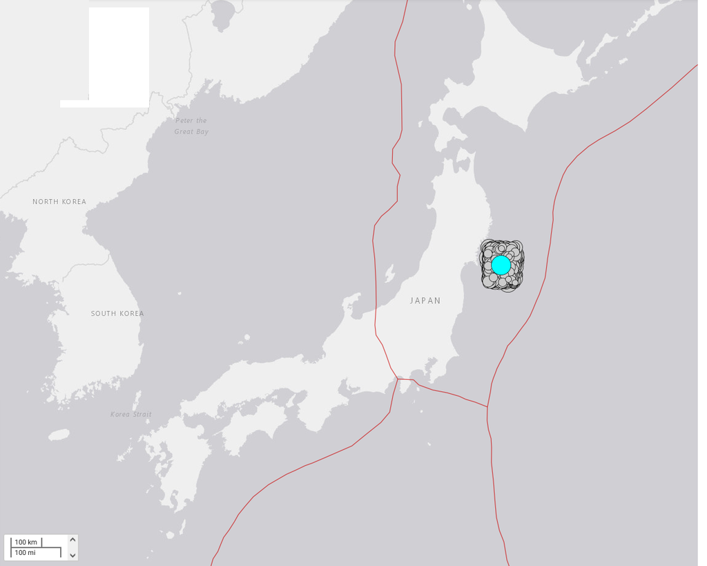

**Figure 1.** Historic earthquake data around the Sendai earthquake epicenter (colored in blue).

The first 6 lines from the historical earthquake data follow. Note that I have removed an earthquake of magnitude zero from the data.

```r
library(dplyr)
library(flextable)
quakes<-read.csv("japan_quakes_usgs_1Jan1900_9Nov2022.csv",
                 sep = ",", header = TRUE) %>%
  filter(mag!=0)

# List pretty table
set_flextable_defaults(font.size=12)
flextab=flextable(head(quakes))
set_table_properties(flextab,

                     opts_html = list(
                       shadow=FALSE,
                       scroll=list()
                       )
                     )
```

| time | latitude | longitude | depth | mag | magType | nst | gap | dmin | rms | net | id | updated | place | type | horizontalError | depthError | magError | magNst | status | locationSource | magSource |
| --- | --- | --- | --- | --- | --- | --- | --- | --- | --- | --- | --- | --- | --- | --- | --- | --- | --- | --- | --- | --- | --- |
| 2022-10-17T23:48:41.404Z | 37.8901 | 142.0877 | 60.307 | 4.4 | mb | 30 | 134 | 3.002 | 0.70 | us | us6000ivik | 2022-11-07T05:42:08.040Z | 90 km SE of Ishinomaki, Japan | earthquake | 7.78 | 8.260 | 0.170 | 10 | reviewed | us | us |
| 2022-10-13T22:30:53.913Z | 37.8087 | 142.0349 | 45.157 | 4.6 | mb | 28 | 126 | 3.070 | 0.67 | us | us6000iuvf | 2022-11-05T21:12:57.040Z | 93 km SE of Ishinomaki, Japan | earthquake | 9.18 | 8.414 | 0.193 | 8 | reviewed | us | us |
| 2022-10-11T14:49:34.398Z | 38.3815 | 142.2716 | 56.699 | 4.4 | mb | 17 | 149 | 2.579 | 0.49 | us | us6000iuch | 2022-10-17T21:19:21.040Z | 84 km E of Ishinomaki, Japan | earthquake | 6.59 | 9.663 | 0.219 | 6 | reviewed | us | us |
| 2022-10-05T19:04:11.936Z | 38.7587 | 141.9998 | 64.868 | 4.8 | mb | 77 | 93 | 2.152 | 0.58 | us | us6000ir61 | 2022-10-12T17:35:09.067Z | 42 km SE of ?funato, Japan | earthquake | 7.65 | 6.002 | 0.069 | 65 | reviewed | us | us |
| 2022-10-02T23:51:41.384Z | 37.9259 | 142.7940 | 30.586 | 4.1 | mb | 18 | 144 | 3.158 | 0.26 | us | us6000iruc | 2022-10-08T22:31:41.040Z | 141 km ESE of Ishinomaki, Japan | earthquake | 9.81 | 6.337 | 0.262 | 4 | reviewed | us | us |
| 2022-10-02T22:45:34.555Z | 38.4815 | 142.4702 | 35.000 | 4.5 | mb | 32 | 137 | 2.548 | 1.48 | us | us6000iqan | 2022-10-11T21:13:04.040Z | 92 km SE of ?funato, Japan | earthquake | 7.50 | 1.930 | 0.156 | 12 | reviewed | us | us |

The data include 867 events ranging from 3.5 to 9.1 on the Richter scale. As we are, for the moment, only interested in the year and the frequency of the magnitude of the earthquakes, we subset the data as follows:

```r
library(lubridate)

yrs=with(quakes, as.numeric((max(date(time))-min(date(time)))/365.25))
quake.freqs=quakes %>%
  count(mag) %>%
  mutate(pct=n/yrs)

flextable(head(quake.freqs))
```

| mag | n | pct |
| --- | --- | --- |
| 3.5 | 2 | 0.02088814 |
| 3.6 | 2 | 0.02088814 |
| 3.7 | 3 | 0.03133221 |
| 3.8 | 4 | 0.04177628 |
| 3.9 | 7 | 0.07310849 |
| 4.0 | 26 | 0.27154581 |

Notice the code above

```r
yrs<-as.numeric(max(date(ymd_hms(quakes$time)))-min(date(ymd_hms(quakes$time))))/365.25
```

This code takes the maximum date 2022-10-17 of the database and subtracts the minimum (earliest) date 1927-01-17 resulting in 34972 days of data. To turn this into years, as required by the Gutenberg-Ricther model, we divide by 365.25 (the average number of days in a year). This gives us approximately 95.7 *years* of data. Note also that you must change this to numeric, since the default output is of `difftime` class!

The log-10-transformed frequencies are plotted in the following figure.

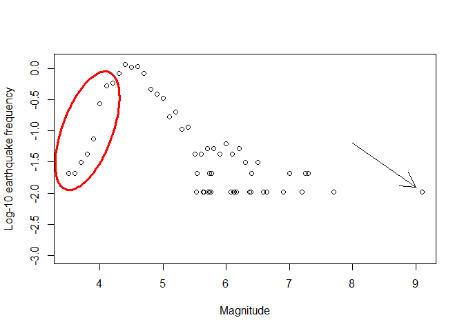

**Figure 2**. Scatter plot of earthquakes by magnitude.

```r
# USGS earthquake data
library(plotrix)
plot(quake.freqs$mag, log10(quake.freqs$pct), ylim = c(-3,.1),
     xlim = c(min(quake.freqs$mag), max(quake.freqs$mag)),
     ylab = "Log-10 earthquake frequency", xlab = "Magnitude")
arrows(8, -1.2, 9, -1.9 )
draw.ellipse(3.8, -1, a = .4, b = 1, angle = 160, lwd=3, border = 'red')
```

In the above figure we see the 9.1 Sendai earthquake (arrow). We also notice an number of earthquakes of smaller magnitude which, paradoxically, have lower than expected frequency. This phenomenon may be due to under-reporting of small earthquakes.

## Exploratory data analysis

To fit the Gutenberg-Richter model we will have to discard the section of the frequency spectrum which is not consistent with the linear trend implied in the Gutenberg-Richter model. This is an arbitrary decision on my part, because I am fairly convinced that this is an artifact caused by under-reporting of smaller-magnitude earthquakes and not a feature of the data; maybe I am wrong. In any case, doing this by eye will produce potentially biased estimates of $b$, so I choose several options for the cutoff and see what happens. We will also remove from the data set the Sendai earthquake, as this is the earthquake whose probability we are trying to estimate. In addition, the magnitude of this earthquake is so large, that the estimates will inevitably be sensitive to whether this point is in the data set or not, so it must be removed before proceeding.

I will create a function which will remove all earthquakes below a threshold and produce the estimates of $b$. Here it goes:

```r
bvalue<-function(minmag, data){
  subdata<-subset(data, mag>minmag)
  lm.fit<-lm(log10(pct)~mag, data = subdata)
  return(lm.fit)
}
```

Let’s see what difference it makes on the estimation of $b$ to change the minimum value of the magnitudes entering in the estimation. We will start with a threshold of $M=3.5$ (i.e., removing no earthquakes, as $M=3.5$ is the lowest magnitude in the data) and going up to $M=5$:

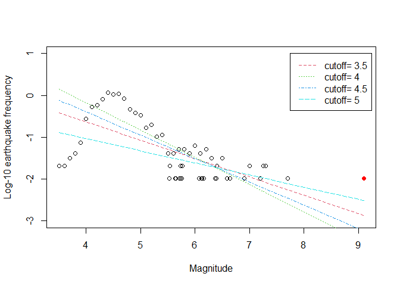

**Figure 3.** Various estimates of earthquake risk

```r
subdata<-rbind(subset(quake.freqs, mag <9), data.frame(mag = 9.1, n = NA, pct = NA))
plot(log10(pct)~mag, quake.freqs[quake.freqs$mag<9.1,],
     ylim = c(-3,1), xlim = c(min(quake.freqs$mag),
                              max(quake.freqs$mag)),
     ylab = "Log-10 earthquake frequency", xlab = "Magnitude")
points(log10(pct)~mag, data=quake.freqs[quake.freqs$mag>9,],
       pch=16, col='red')
colorcount=2
for(i in seq(3.5, 5, by = 0.5)){
lines(subdata$mag, predict(bvalue(i, subdata), newdata = subdata),
      lwd = 1, col = colorcount, lty = colorcount)
  colorcount=colorcount+1
}
legend(7.75,1, paste("cutoff=", seq(3.5,5,.5)), lty = 2:5, col = 2:5)
```

It is not straightfoward to choose among these lines. As a criterion of the optimal threshold in some sense, I plot the r-squared values resulting from these models. These are given in the following figure:

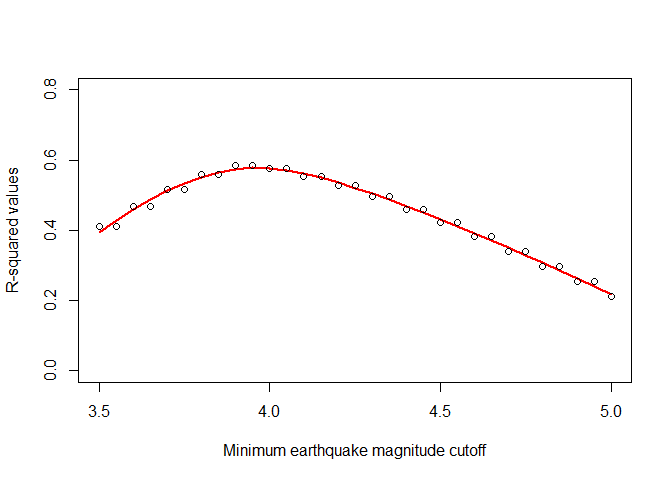

**Figure 4.** R-square values by earthquake magnitude cutoff

```r
rsq<-NULL
bvalue.list<-lapply(seq(3.5,5,0.05), bvalue, quake.freqs)
for(i in 1:length(seq(3.5,5,.05))){
   rsq[i]<-summary(bvalue.list[[i]])$r.squared
}

plot(seq(3.5,5,.05), predict(loess(rsq~seq(3.5,5,.05), span = .6)), type = "l", ylim = c(0, 0.8), col='red', lwd=2,
     ylab = "R-squared values", xlab = "Minimum earthquake magnitude cutoff")
points(seq(3.5,5,.05), rsq)
```

## Regression analysis

Carrying out this model, we can predict the data estimate for the likelihood of the 9.1 magnitude Fukushima earthquake.

```r
opthreshold=unique(quakes$mag[which(rsq==max(rsq))])
fukureg=lm(log10(pct)~mag,
           data=subset(quake.freqs,
                       mag>=opthreshold & mag<9))
p.fukushima<-predict(fukureg, newdata = data.frame(mag=9.1))
```

The estimates for $a$ and $b$ from this model are, respectively, $\hat a=2.31$ and $\hat b=-0.632$. This produces the estimate of the frequency (and thus the probability) of the occurrence of a Fukushima-type event as
$$\widehat{\log_{10}(f)}=\hat a+\hat b(9.1)=2.31 -0.632(9.1)=-3.45$$

In other words, the probability that an earthquake like the Fukushima one would occur is $f=10^{-3.45}=0.00036$ or once in 2798 years.

# Conclusion